# Insight: Node Security Issues

Ronauli Silva

06/29/2018

## TLDR

This notebook is written in [R Markdown](http://rmarkdown.rstudio.com) Notebook. I guess the title is pretty much conveys the content :p

## How

So the idea is to see what’s happening out there, see common issues, and it would be best to find it through a website that gather reports of node security issues. The best website I could find is [NodeSecurity.io](https://nodesecurity.io), and scraping the data. Thanks for Ramzi and Neel, by expanding the scraper range via connected link (github repo, hackerone report, npm keywords).

### Data Source

1. Go to nodesecurity.io/advisories, we get:
   - Package name
   - Severity, level of damage. On range 1-10
   - Version, both vulnerable and patched one(if any)
   - Link to npm page of respective package
2. From NSP detail page, we get the hackerOne link.
3. From hackerone link, we gather these information as strings
   - Vulnerability, e.g: Interospection graphql query leaks sensitive data.
   - Impact, e.g: Execute bash script via request parameter
4. From npm page, we gather:
   - Keywords (easier to handle)
5. From Github API, we get:
   - Description/functionality of respective package

### How

So we run the scraper on node.js, and manage to find the insight using R.

## Insights

```r
basic.data <- data.frame(rawData$disclosed_at)
```

### Functionality with High Severity

```r
titleCorpus <- VCorpus(VectorSource(rawData$title))
clean <- function(corpus){
  corpus <- tm_map(corpus, stripWhitespace)
  corpus <- tm_map(corpus, removePunctuation)
  corpus <- tm_map(corpus, content_transformer(tolower))
  corpus <- tm_map(corpus, removeWords, stopwords("en"))
    return(corpus)
}
cleanFunctionalityData <- clean(titleCorpus)
# stemming
stemFunc <- content_transformer(function(x){
  paste(sapply(words(x),stemDocument),collapse = " ")
})
# stemmed functionality string
stemFnData <- tm_map(cleanFunctionalityData, stemFunc)
```

#### Bar chart: Most Frequent Word in Titles

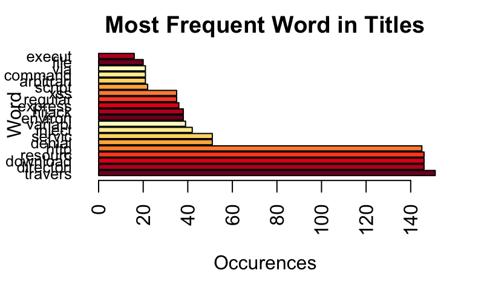

```r
dtm <- TermDocumentMatrix(stemFnData)
mat <- as.matrix(dtm)
# sort by frequency and print the first 20]
sortedData <- sort(rowSums(mat), decreasing = TRUE )
first20 <- sortedData[1:20];
d <- data.frame(word = names(sortedData), freq=sortedData)
# head(d, 20)
## Find a range of y's that'll leave sufficient space above the tallest bar
bpFreqWord <- barplot(sortedData[1:20]
        ,main='Most Frequent Word in Titles'
        ,horiz=TRUE
        ,xlab="Occurences"
        ,ylab="Word"
        ,col=rev(brewer.pal(9, "YlOrRd"))
        ,las=2
        ,cex.names=0.8)
```

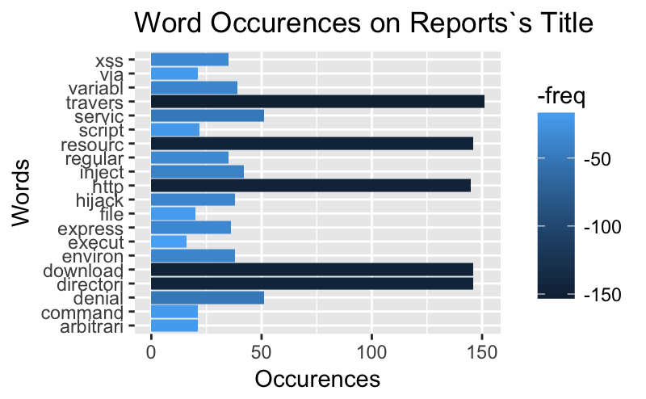

```r
ggplot(data =yy  , aes(x = word, y = freq, fill=-freq)) +
    geom_bar(stat="identity") +
    coord_flip() +
    scale_color_gradient2(low = "lightblue", high = "darkblue", midpoint=75) +
    labs(title = 'Word Occurences on Reports`s Title',
         x = 'Words',
         y = 'Occurences')
```

[figure not shown]

```r
df <- data.frame(rawData$title, rawData$severity)
names(df) <- c("title","severity")
df <- mutate(df, id = rownames(df))
df <- df[!(is.na(df$title) | df$title==""), ]
# create a document term matrix
dtm <- CreateDtm(doc_vec = df$title, # character vector of documents
                 doc_names = df$id, # document names
                 ngram_window = c(1, 2), # minimum and maximum n-gram length
                 stopword_vec = c(tm::stopwords("english"), # stopwords from tm
                                  tm::stopwords("SMART")), # this is the default value
                 lower = TRUE, # lowercase - this is the default value
                 remove_punctuation = TRUE, # punctuation - this is the default
                 remove_numbers = TRUE, # numbers - this is the default
                 verbose = FALSE, # Turn off status bar for this demo
                 cpus = 2) # default is all available cpus on the system
# construct the matrix of term counts to get the IDF vector
tf_mat <- TermDocFreq(dtm)
# TF-IDF and cosine similarity
tfidf <- t(dtm[ , tf_mat$term ]) * tf_mat$idf
tfidf <- t(tfidf)
csim <- tfidf / sqrt(rowSums(tfidf * tfidf))
csim <- csim %*% t(csim)
cdist <- as.dist(1 - csim)
hc <- hclust(cdist, method="ward.D")
clustering <- cutree(hc, 10)
plot(hc, main = "Hierarchical clustering of 100 NIH grant abstracts",
     ylab = "", xlab = "", yaxt = "n")
rect.hclust(hc, 10, border = "red")
```

```r
p_words <- colSums(dtm) / sum(dtm)
cluster_words <- lapply(unique(clustering), function(x){
  rows <- dtm[ clustering == x , ]

  # for memory's sake, drop all words that don't appear in the cluster
  rows <- rows[ , colSums(rows) > 0 ]

  colSums(rows) / sum(rows) - p_words[ colnames(rows) ]
})
# create a summary table of the top 5 words defining each cluster
cluster_summary <- data.frame(cluster = unique(clustering),
                              size = as.numeric(table(clustering)),
                              top_words = sapply(cluster_words, function(d){
                                paste(
                                  names(d)[ order(d, decreasing = TRUE) ][ 1:5 ],
                                  collapse = ", ")
                              }),
                              stringsAsFactors = FALSE)
cluster_summary
```

| cluster | size | top_words |
| --- | --- | --- |
| 1 | 186 | xss, path, injection, server, file |
| 2 | 18 | site, site_scripting, cross_site, scripting, cross |
| 3 | 11 | denial_service, service, denial, NA, NA |
| 4 | 35 | regular_expression, regular, expression_denial, expression, denial_service |
| 5 | 10 | memory, exposure, memory_exposure, remote_memory, remote |
| 6 | 133 | directory_traversal, directory, traversal, NA, NA |
| 7 | 14 | code, code_execution, execution, arbitrary_code, arbitrary |
| 8 | 11 | command_injection, command, injection, potential_command, potential |
| 9 | 38 | hijacked, variables, environment, hijacked_environment, environment_variables |
| 10 | 145 | downloads, resources_http, downloads_resources, resources, http |

Wordcloud of First Cluster (xss)

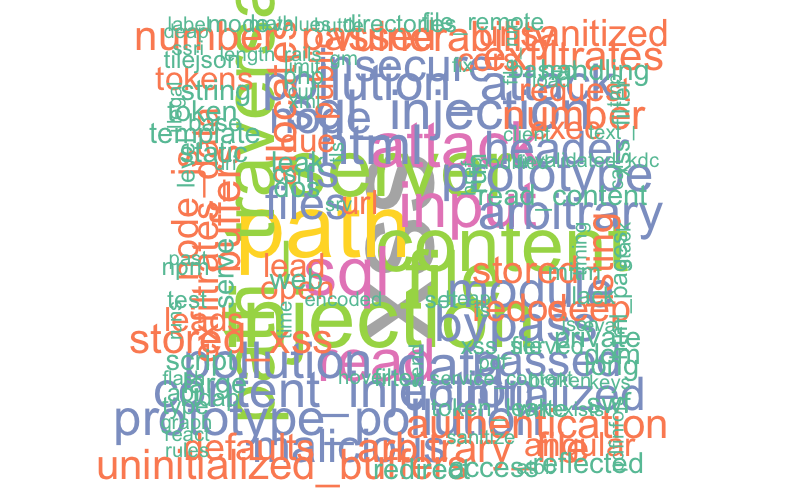

```r
wordcloud(words = names(cluster_words[[1]]),
                     freq = cluster_words[[1]],
                     random.order = F,
                     colors=brewer.pal(8, "Set2"),
                     main = "Top words in cluster 100")
```

#### Wordcloud - All

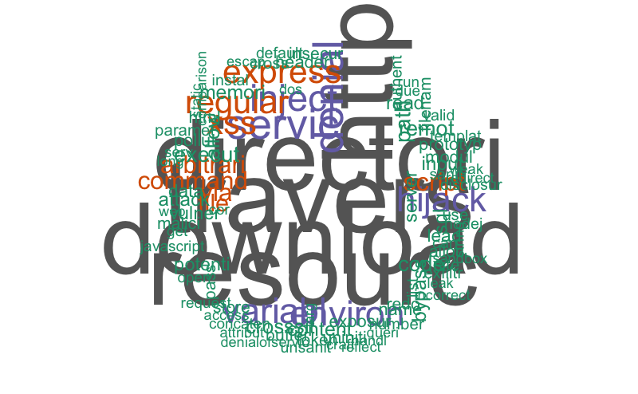

Thank you.